# task11

MildaPie

2016 m spalis 28 d

## Tiesinė regresija

Pakete datasets yra duomenų masyvas longley. Iš šio kintamųjų padarykite tiesinę regresiją, kur prognozuojamas kintamasis būtų GNP, o regresosius Employed. Jums reikia: Įvertinti paprastosios tiesinės regresijos modelį. Pateikti modelio summary ir pakomentuoti ką reiškia gauti skaičiai. Kaip interpretuoti gautus rezultatus? Padarykite modelio prognozes taškuose 62,65,68 62,65,68 . Išbrėžkite kintamųjų sklaidos diagramą kartu su tiesinės regresijos tiese ir naujomis prognozėmis. Grafiką pateikite su pilna legenda, kurioje būtų nurodyti visi žymėjimai.

#### Modelio įvertinimas

```r
names(longley)
```

```
## [1] "GNP.deflator" "GNP"          "Unemployed"   "Armed.Forces"
## [5] "Population"   "Year"         "Employed"
```

```r
longley.lm <- lm(GNP ~ Employed, data = longley)

 summary(lm(GNP~Employed, longley))
```

```
##
## Call:
## lm(formula = GNP ~ Employed, data = longley)
##
## Residuals:
##     Min      1Q  Median      3Q     Max
## -39.223 -11.920   0.855  14.882  23.555
##
## Coefficients:
##              Estimate Std. Error t value Pr(>|t|)
## (Intercept) -1430.482     89.361  -16.01 2.15e-10 ***
## Employed       27.836      1.366   20.37 8.36e-12 ***
## ---
## Signif. codes:  0 '***' 0.001 '**' 0.01 '*' 0.05 '.' 0.1 ' ' 1
##
## Residual standard error: 18.58 on 14 degrees of freedom
## Multiple R-squared:  0.9674, Adjusted R-squared:  0.965
## F-statistic: 415.1 on 1 and 14 DF,  p-value: 8.363e-12
```

Residuals - nusako skirtumą tarp kintamojo tikrųjų reikšmių ir ir regresijos nustatytų. Daugeliu atvejų reikia, kad residuals primintų normalūjų skirstinį. Signif codes - žvaigždutės atitinka p reikšmę. *** reiškia, kad nedidelė tikimybė, jog nėra priklausomybės tarp y ir x. Estimated coefficient- regresija įvertintas krypties koeficientas. Standard error - matuoja koeficiento įverčio variaciją. Kuo mažesnis, tuo geriau. (Turėtų būti mažesnis, nei coefficient estimate) residual standard error- residuals standartinis nuokrypis. Turėtų būti proporcingas kvantiliams prie Residuals. Multiple R-squared- matuoja goodness of fit. Kuo didesnis tuo geriau (iki 1). F-statistic- F testo rezultatas. Tikrina, ar modelis su daugiau parametrų (dabartinis) geresnis, nei su mažiau.

#### Prognozės

```r
longley.lm <- lm(GNP ~ Employed, data = longley)
predict(longley.lm,newdata=data.frame(Employed=c(62,65,68)))
```

```
##        1        2        3
## 295.3656 378.8743 462.3831
```

#### Sklaidos diagrama

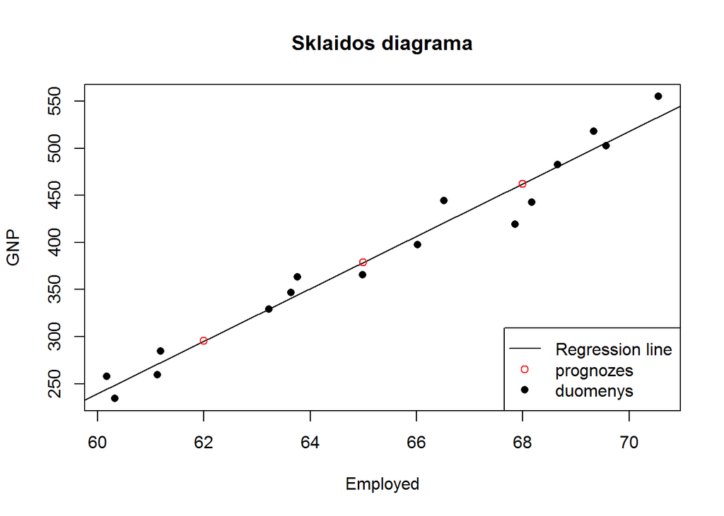

```r
longley.lm <- lm(GNP ~ Employed, data = longley)
 plot(GNP ~ Employed, data = longley, pch=16, main="Sklaidos diagrama", xlab="Employed", ylab = "GNP")
 abline(coef(longley.lm))
 predict(longley.lm,newdata=data.frame(Employed=c(62,65,68)))->pre

 points(c(62,65,68), pre, col=2)
 legend("bottomright", legend = c("Regression line","prognozes", "duomenys" ), col = c(1,2,1), lty = c(1,NA,NA), pch=c(NA, 1, 16) )
```

# Literatūra

“Introduction to Probability and Statistics Using R”, G. Jay Kerns

https://www.rstudio.com/wp-content/uploads/2015/02/rmarkdown-cheatsheet.pdf

http://blog.yhat.com/posts/r-lm-summary.html